# p8105_hw5_cev2129

2024-11-14

```r
library(tidyverse)
library(rvest)
set.seed(1)
```

**Problem 1**

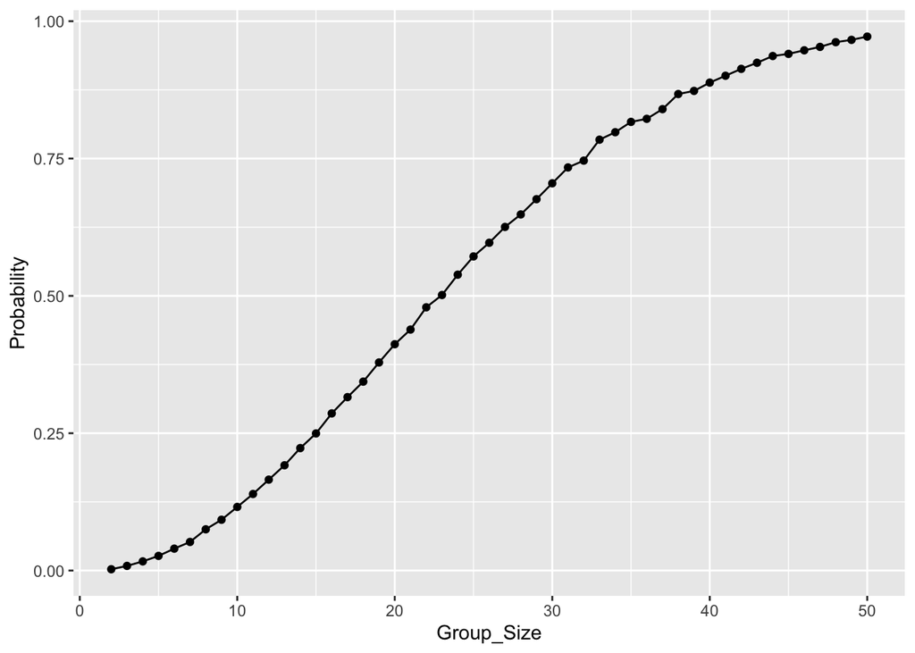

```r
bday_function = function(n) {
  bday <- sample(1:365, n, replace = TRUE)
  if (length(unique(bday)) < n) {
    return(TRUE)
  } else {
    return(FALSE)
  }
}

bday_prob = function(max_group_size, simulations = 10000) {
  prob = numeric(max_group_size - 1)
  for (n in 2:max_group_size) {
    results <- replicate(simulations, bday_function(n))
    prob[n - 1] <- mean(results)
  }
  return(prob)
  }

group_sizes = 2:50
prob = bday_prob(50)

bday_prob_data = data.frame(Group_Size = group_sizes, Probability = prob)

ggplot(bday_prob_data, aes(x = Group_Size, y = Probability)) +
  geom_line() +
  geom_point()
```

The graph shows that there is a positive association between group size and probability that two people share a birthday.

**Problem 2**

```r
q2_t_test = function(mu, iterations = 5000) {
  replicate(iterations, {
    data <- rnorm(n = 30, mean = mu, sd = 5)
    t_test <- t.test(data, mu = 0)
    broom::tidy(t_test)
  }, simplify = FALSE) |>
    bind_rows() |>
    mutate(mu = mu)
}

values = c(0, 1, 2, 3, 4, 5, 6)

q2_results = map_dfr(values, q2_t_test)

q2_power = q2_results |>
  group_by(mu) |>
  summarize(
    mean_estimate = mean(estimate),
    power = mean(p.value < 0.05)
  )

q2_power
```

```
## # A tibble: 7 × 3
##      mu mean_estimate power
##   <dbl>         <dbl> <dbl>
## 1     0       0.00500 0.05
## 2     1       0.992   0.187
## 3     2       2.01    0.569
## 4     3       3.01    0.887
## 5     4       4.01    0.987
## 6     5       5.01    0.999
## 7     6       6.00    1
```

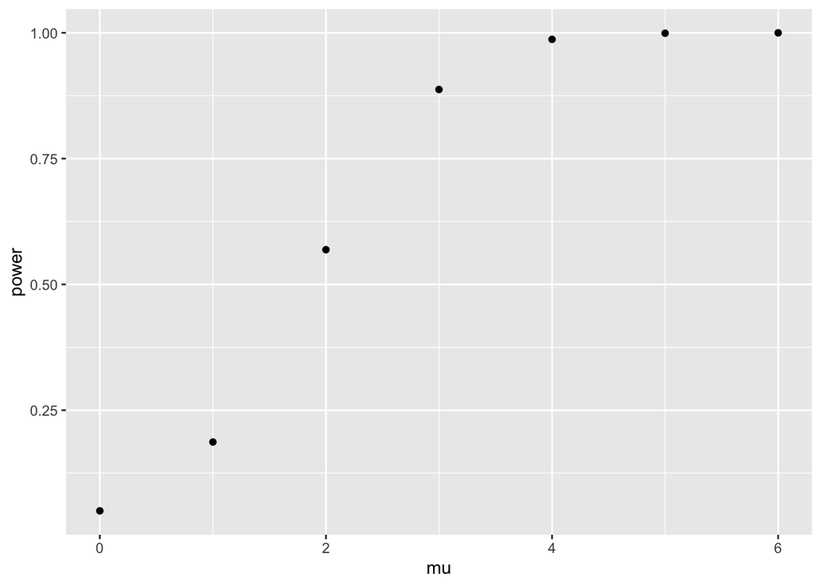

```r
library(ggplot2)
ggplot(q2_power, aes(x = mu, y = power)) +
  geom_point()
```

Effect size and Power have a positive association. As the true value of mu increases, the difference between the true mu value and the null hypothesized value increases as well, which is known as the effect size. This makes it more feasible to detect a difference, which increases power. This is reflected in the graph above, as the true value of mu increases with power.

```r
null_rejected = q2_results |>
  group_by(mu) |>
  summarize(
    mean_rejected = mean(estimate[p.value < 0.05], na.rm = TRUE)
  )

q2 = q2_power |>
  left_join(null_rejected, by = "mu")

q2
```

```
## # A tibble: 7 × 4
##      mu mean_estimate power mean_rejected
##   <dbl>         <dbl> <dbl>         <dbl>
## 1     0       0.00500 0.05          0.236
## 2     1       0.992   0.187         2.21
## 3     2       2.01    0.569         2.62
## 4     3       3.01    0.887         3.20
## 5     4       4.01    0.987         4.04
## 6     5       5.01    0.999         5.01
## 7     6       6.00    1             6.00
```

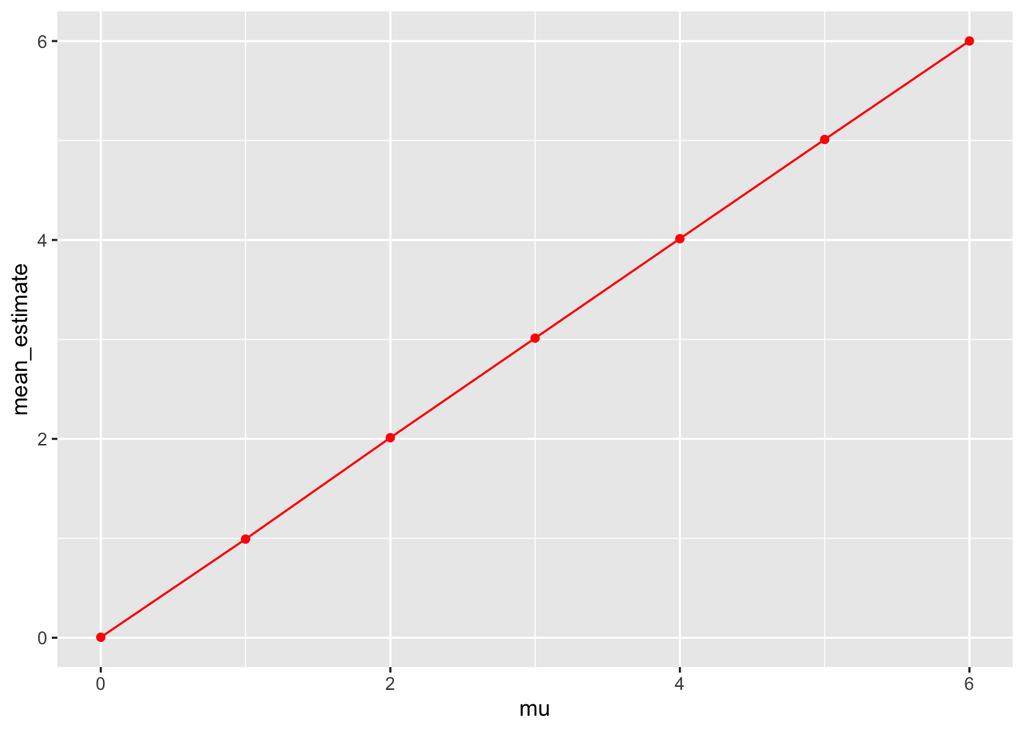

```r
plot1 = ggplot(q2, aes(x = mu)) +
  geom_line(aes(y = mean_estimate), color = "red",linetype = "solid") +
  geom_point(aes(y = mean_estimate), color = "red")
plot1
```

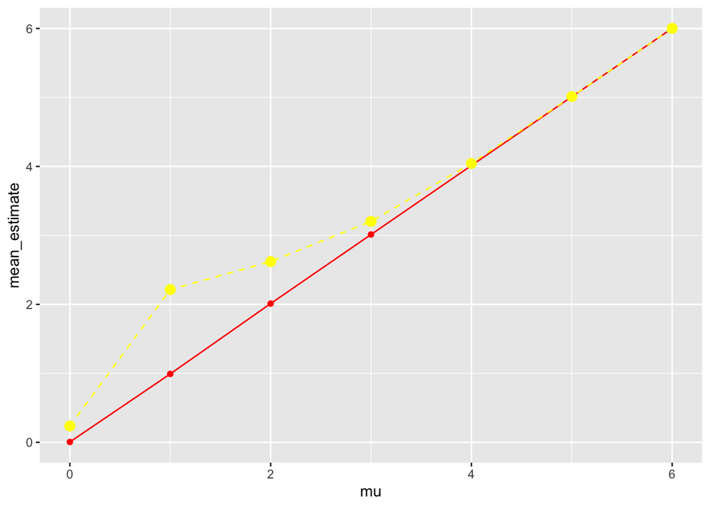

```r
plot2 = plot1 + geom_line(aes(y = mean_rejected), color = "yellow", linetype = "dashed") +
  geom_point(aes(y = mean_rejected), size = 3, color = "yellow")

plot2
```

The sample average of the estimates of 𝜇̂ across the tests where the null hypothesis is rejected is approximately equal to the true value of 𝜇 for certain values of 𝜇, specifically for 𝜇 = 4, 5, and 6. This is because for larger effect sizes, we tend to have a larger sample of 𝜇̂ values, and with a larger sample size, the average of these estimates tends to be closer to the true mean.

**Problem 3**

```r
library(dplyr)
library(readr)

homicide_data = read_csv("https://raw.githubusercontent.com/washingtonpost/data-homicides/refs/heads/master/homicide-data.csv")
homicide_data = homicide_data |>
  mutate(city_state = paste(city, state, sep = ", "))

summary = homicide_data |>
  group_by(city_state) |>
  summarize(
    total = n(),
    unsolved = sum(disposition %in% c("Closed without arrest", "Open/No arrest"))
  )
summary
```

```
## # A tibble: 51 × 3
##    city_state      total unsolved
##    <chr>           <int>    <int>
##  1 Albuquerque, NM   378      146
##  2 Atlanta, GA       973      373
##  3 Baltimore, MD    2827     1825
##  4 Baton Rouge, LA   424      196
##  5 Birmingham, AL    800      347
##  6 Boston, MA        614      310
##  7 Buffalo, NY       521      319
##  8 Charlotte, NC     687      206
##  9 Chicago, IL      5535     4073
## 10 Cincinnati, OH    694      309
## # ℹ 41 more rows
```

```r
baltimore = homicide_data |>
  filter(city_state == "Baltimore, MD")

prop_test = prop.test(
  x = sum(baltimore[["disposition"]] %in% c("Closed without arrest", "Open/No arrest")),
  n = nrow(baltimore)) |>
  broom::tidy()

proportion_estimate = prop_test |>
  pull(estimate)

conf_interval = prop_test |>
  select(conf.low, conf.high)
```

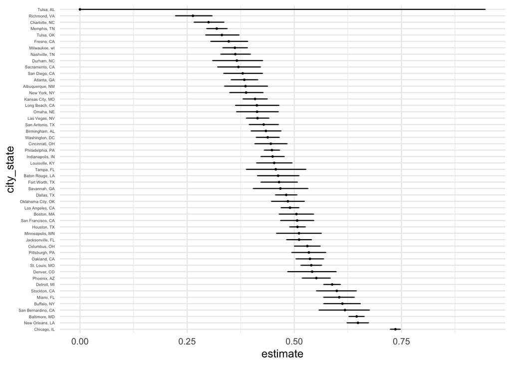

```r
city_prop_tests <- homicide_data |>
  group_by(city_state) |>
  summarise(
    results = list(prop.test(
      x = sum(disposition %in% c("Closed without arrest", "Open/No arrest")),
      n = n()
    ))
  ) |>
  mutate(
    tidy = purrr::map(results, broom::tidy)
  ) |>
  unnest(cols = c(tidy)) |>
  select(city_state, estimate, conf.low, conf.high)
city_plot <- city_prop_tests |>
  arrange(desc(estimate)) |>
  mutate(city_state = factor(city_state, levels = city_state)) |>
  ggplot(aes(x = city_state, y = estimate)) +
  geom_point(size = 0.5) +
  geom_errorbar(aes(ymin = conf.low, ymax = conf.high), width = 0.1) +
  coord_flip() +
  theme_minimal() +
  theme(
    axis.text.y = element_text(size = 4))

city_plot
```